# Problem Set 4

#### Your first task is to create a scatterplot of price vs x.

```r
library(ggplot2)
data(diamonds)
summary(diamonds)
```

```
##      carat               cut        color        clarity
##  Min.   :0.2000   Fair     : 1610   D: 6775   SI1    :13065
##  1st Qu.:0.4000   Good     : 4906   E: 9797   VS2    :12258
##  Median :0.7000   Very Good:12082   F: 9542   SI2    : 9194
##  Mean   :0.7979   Premium  :13791   G:11292   VS1    : 8171
##  3rd Qu.:1.0400   Ideal    :21551   H: 8304   VVS2   : 5066
##  Max.   :5.0100                     I: 5422   VVS1   : 3655
##                                     J: 2808   (Other): 2531
##      depth           table           price             x
##  Min.   :43.00   Min.   :43.00   Min.   :  326   Min.   : 0.000
##  1st Qu.:61.00   1st Qu.:56.00   1st Qu.:  950   1st Qu.: 4.710
##  Median :61.80   Median :57.00   Median : 2401   Median : 5.700
##  Mean   :61.75   Mean   :57.46   Mean   : 3933   Mean   : 5.731
##  3rd Qu.:62.50   3rd Qu.:59.00   3rd Qu.: 5324   3rd Qu.: 6.540
##  Max.   :79.00   Max.   :95.00   Max.   :18823   Max.   :10.740
##
##        y                z
##  Min.   : 0.000   Min.   : 0.000
##  1st Qu.: 4.720   1st Qu.: 2.910
##  Median : 5.710   Median : 3.530
##  Mean   : 5.735   Mean   : 3.539
##  3rd Qu.: 6.540   3rd Qu.: 4.040
##  Max.   :58.900   Max.   :31.800
##
```

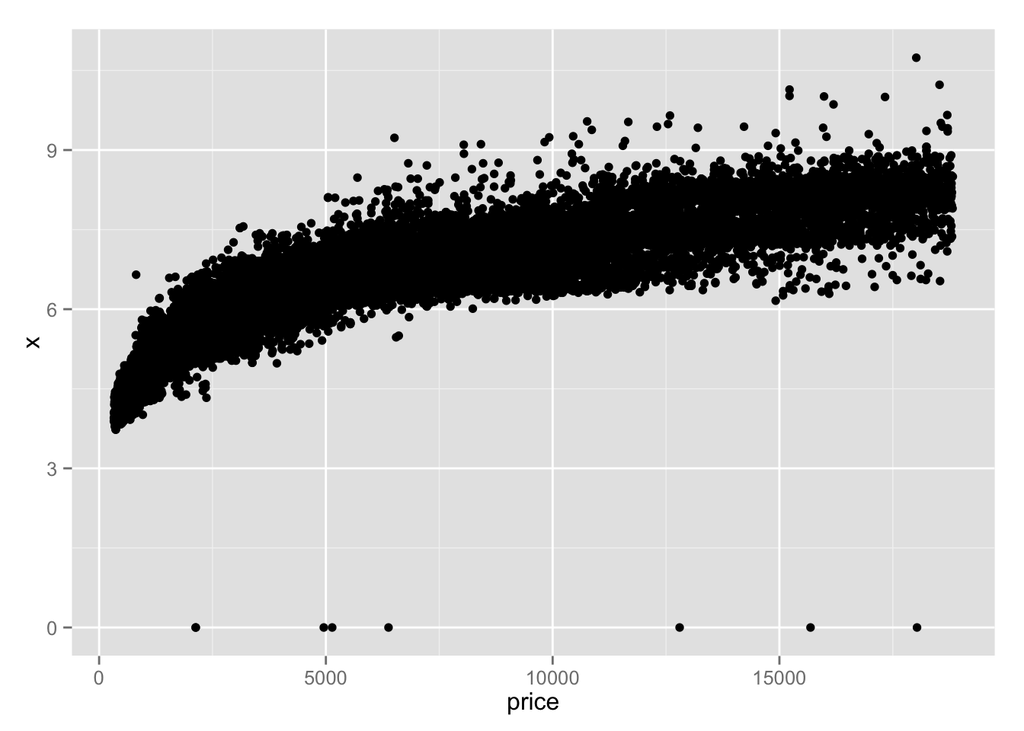

```r
ggplot(data=diamonds, aes(price,x)) + geom_point()
```

```r
cor.test(diamonds$price, diamonds$x)
```

```
##
##  Pearson's product-moment correlation
##
## data:  diamonds$price and diamonds$x
## t = 440.16, df = 53938, p-value < 2.2e-16
## alternative hypothesis: true correlation is not equal to 0
## 95 percent confidence interval:
##  0.8825835 0.8862594
## sample estimates:
##       cor
## 0.8844352
```

```r
cor.test(diamonds$price, diamonds$y)
```

```
##
##  Pearson's product-moment correlation
##
## data:  diamonds$price and diamonds$y
## t = 401.14, df = 53938, p-value < 2.2e-16
## alternative hypothesis: true correlation is not equal to 0
## 95 percent confidence interval:
##  0.8632867 0.8675241
## sample estimates:
##       cor
## 0.8654209
```

```r
cor.test(diamonds$price, diamonds$z)
```

```
##
##  Pearson's product-moment correlation
##
## data:  diamonds$price and diamonds$z
## t = 393.6, df = 53938, p-value < 2.2e-16
## alternative hypothesis: true correlation is not equal to 0
## 95 percent confidence interval:
##  0.8590541 0.8634131
## sample estimates:
##       cor
## 0.8612494
```

#### Create a simple scatter plot of price vs depth

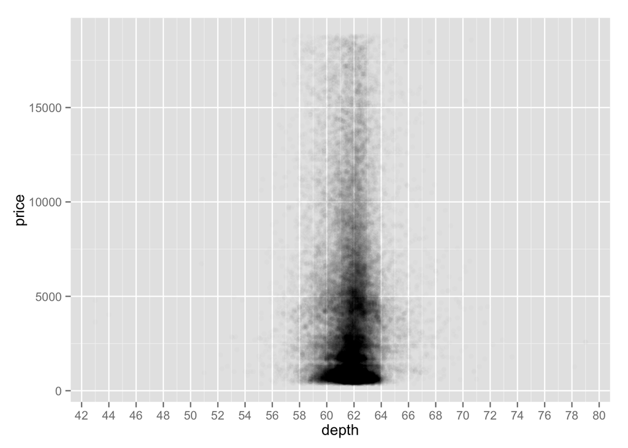

```r
ggplot(data=diamonds, aes(depth, price)) + geom_point(alpha=0.01) + scale_x_continuous(breaks = seq(40,80,2))
```

```r
cor.test(diamonds$depth,diamonds$price)
```

```
##
##  Pearson's product-moment correlation
##
## data:  diamonds$depth and diamonds$price
## t = -2.473, df = 53938, p-value = 0.0134
## alternative hypothesis: true correlation is not equal to 0
## 95 percent confidence interval:
##  -0.019084756 -0.002208537
## sample estimates:
##        cor
## -0.0106474
```

#### Create a scatterplot of price vs carat and omit the top 1% of price and carat values.

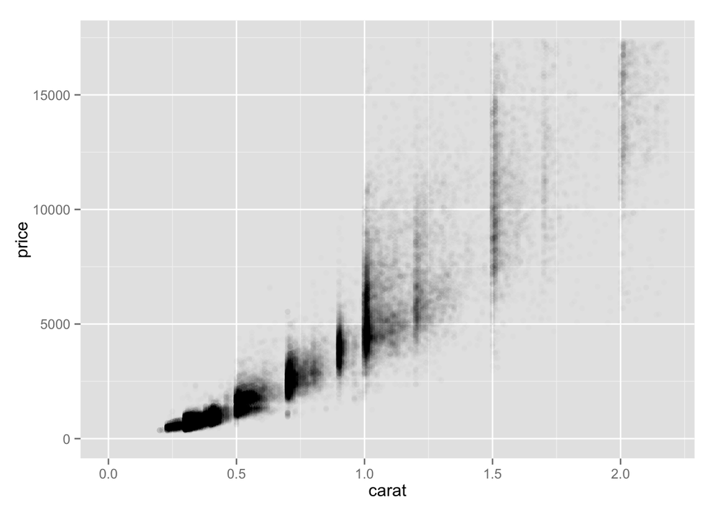

```r
ggplot(data=diamonds, aes(carat, price)) + geom_point(alpha=0.01) + xlim(0, quantile(diamonds$carat, .99)) + ylim(0, quantile(diamonds$price, .99))
```

#### Create a scatterplot of price vs. volume (x * y * z). This is a very rough approximation for a diamond’s volume.

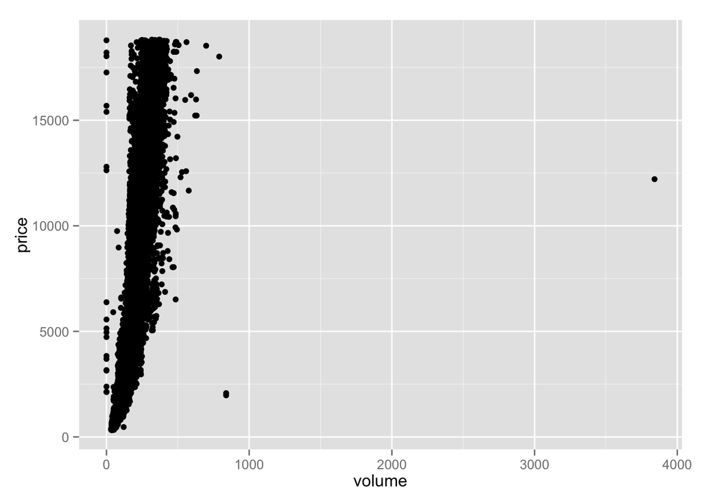

```r
diamonds$volume <- diamonds$x * diamonds$y * diamonds$z
ggplot(data=diamonds, aes(volume, price)) + geom_point()
```

```r
library(plyr)
count(diamonds$volume == 0)
```

```
##       x  freq
## 1 FALSE 53920
## 2  TRUE    20
```

#### Subset the data to exclude diamonds with a volume greater than or equal to 800. Also, exclude diamonds with a volume of 0. Adjust the transparency of the points and add a linear model to the plot.

```r
with(subset(diamonds, volume!=0 & volume < 800), cor.test(price,volume))
```

```
##
##  Pearson's product-moment correlation
##
## data:  price and volume
## t = 559.19, df = 53915, p-value < 2.2e-16
## alternative hypothesis: true correlation is not equal to 0
## 95 percent confidence interval:
##  0.9222944 0.9247772
## sample estimates:
##       cor
## 0.9235455
```

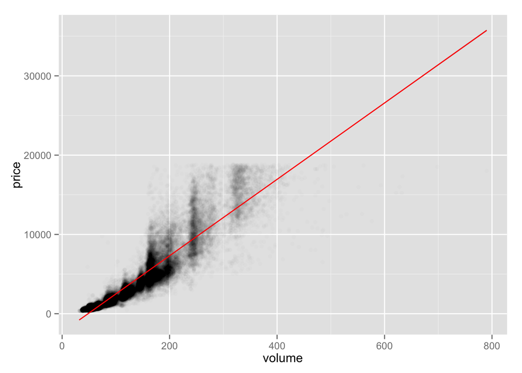

```r
ggplot(data=subset(diamonds, volume!=0 & volume < 800), aes(volume, price)) + geom_point(alpha=0.01) + geom_smooth(method='lm',color='red')
```

#### Use the function dplyr package to create a new data frame containing info on diamonds by clarity. Name the data frame diamondsByClarity

The data frame should contain the following variables in this order.

```
   (1) mean_price
   (2) median_price
   (3) min_price
   (4) max_price
   (5) n
```

where n is the number of diamonds in each level of clarity.

```r
detach("package:plyr", TRUE)
library(dplyr)
diamondsByClarity <- diamonds %>%
  group_by(clarity) %>%
  summarise(mean_price = mean(price),
            median_price = median(price)*1.,
            min_price = min(price),
            max_price = max(price),
            n = n()) %>%
  arrange(clarity)
```

#### We’ve created summary data frames with the mean price by clarity and color. You can run the code in R to verify what data is in the variables diamonds_mp_by_clarity and diamonds_mp_by_color.

Your task is to write additional code to create two bar plots on one output image using the grid.arrange() function from the package gridExtra.

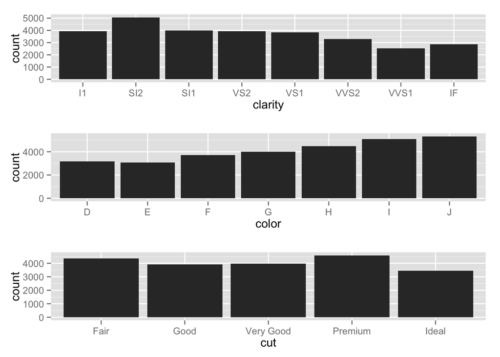

```r
diamonds_by_clarity <- group_by(diamonds, clarity)
diamonds_mp_by_clarity <- summarise(diamonds_by_clarity, mean_price = mean(price))
p1 <- qplot(clarity, data=diamonds_mp_by_clarity, geom ="bar", weight=mean_price)

diamonds_by_color <- group_by(diamonds, color)
diamonds_mp_by_color <- summarise(diamonds_by_color, mean_price = mean(price))
p2 <- qplot(color, data=diamonds_mp_by_color, geom ="bar", weight=mean_price)

diamonds_by_cut <- group_by(diamonds, cut)
diamonds_mp_by_cut <- summarise(diamonds_by_cut, mean_price = mean(price))
p3 <- qplot(cut, data=diamonds_mp_by_cut, geom ="bar", weight=mean_price)

library(gridExtra)
grid.arrange(p1,p2,p3, ncol=1)
```